Weighted Cox Mixed Models  
with Time-Dependent Covariates  
for Recurrent Hospitalizations

Día Panamericano de la Estadística

Claudia Rivera-Rodriguez, PhD

# New Zealand RCD landscape

NZ holds a large research database of RCD (Routinely Collected Data) called the IDI (Integrated Data Infrastructure). It holds de-identified **microdata** about people and households. Access to the IDI is available for research upon request and application.

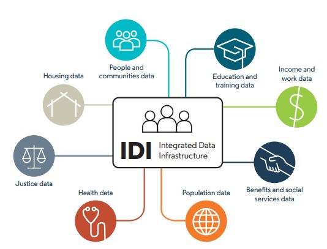

The IDI. Source: https://www.stats.govt.nz/integrated-data/integrated-data-infrastructure/

# Advantages of RCD and Why We Use It

### Economics

- Research funding is limited for data collection.
- RCD offers low-cost inference.
- Data is already gathered.

### Scale

- Large amounts of longitudinal data.
- Systems and quality have improved over time.

### Connectivity

- Modern software handles large sets.
- Opportunities to link databases.

# Technical & Analytical Challenges

### Data Linkage

- **ID Mismatch:** Datasets lack a common unique identifier.
- **Inconsistent Data:** Same IDs may have conflicting info.
- **Temporal inconsistencies:** Longitudinal dates rarely align.

### Data structure

- **Data Quality:** e.g., shifting units of measure over time.
- **Time varying variables:** Handling time-varying vs. static data.
- **Correlation:** e.g., patients within clinics.

### Additional Challenges

- Ethical considerations, data privacy, data governance.

# Application: Hospitalisations

- Our population consists of residents aged 65 years or older in Auckland, a city in New Zealand, living in long-term care from January 2019 to January 2020.
- We have access to hospitalisation data for this population through 2024. This means we have a lot of variables that change over time.

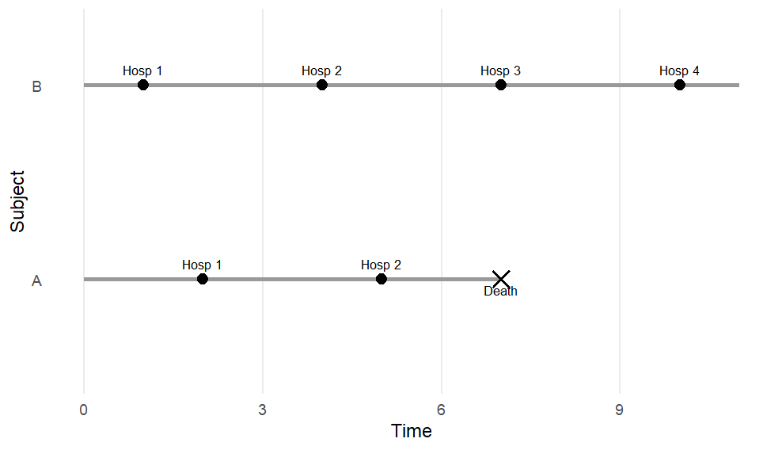

# Application: Hospitalisations

- We link these datasets by placing all events for each subject onto a single timeline and filling the gaps using information carried forward from the most recent observation, whether from health assessments or hospitalisations:

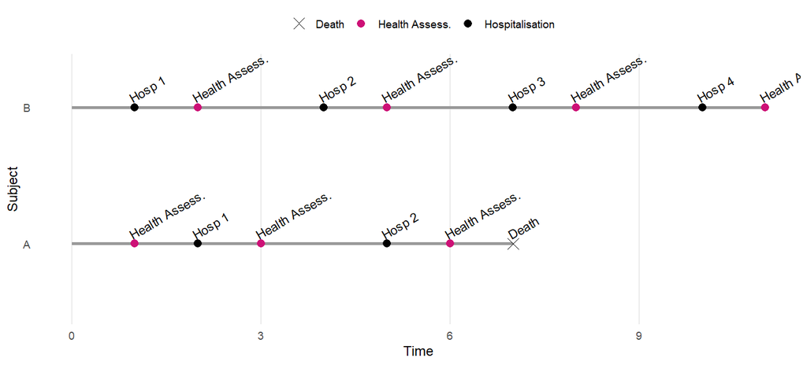

# Application: Hospitalisations

### Key Statistical & Data Challenges

- **Recurrent Events:** Hospitalisations is a recurrent event – time-to-event (correlated)
- **Complex Predictors:** We have time-varying covariates
- **Survival Censoring:** When the study finishes, some people may not have experienced any event– censoring
- **System Missingness:** For our population, some people may not have had any of their health assessments recorded in the system – they could have been made on paper and never made it to the system (Missingness)
- **Methodological Limit:** Standard methods for analysis do not work

# Application: Hospitalisations

### Dataset Structure after data linkage

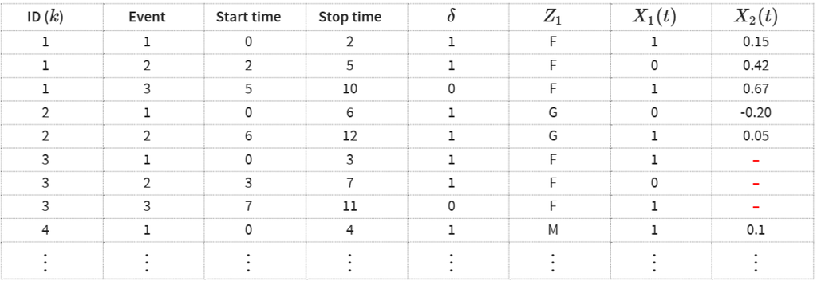

- **Data Structure:** One row per observation, and one ID per subject
- **Complex Predictors:** Time-dependent covariates vary across rows, within the same subject ID
- **System Missingness:** There may be completely missing covariates

# Methods - time-to-event data

- Outcome is the time until an event occurs (death, failure, relapse, …) [see Therneau (2003)]
- Observations may be **right-censored**, left-censored, etc.

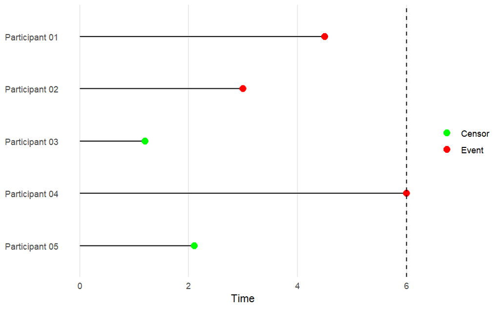